# Progetto di Fondamenti di Scienza dei dati e Laboratorio

## A.A. 2023/2024

## Santarossa Riccardo

[figure not shown]

# Il perchè

- Scoprire il funzionamento dei **tracker** delle statistiche
- Confrontare la mia performance con quella degli altri giocatori

### La mia esperienza

- Giocatore con poca esperienza che ha provato il gioco dopo aver visto un video gameplay

# I dati di partenza

## I dati del server europeo

- Dati in formato Excel
- Dati usati dall'università di Madrid per un'analisi di mercato risalenti al 2019
- Molto dettagliati, contengono **tutte le informazioni** riguardanti una partita

### Link ai dataset

https://data.mendeley.com/datasets/tbspsppv9t/1

[figure not shown]

## I miei dati

- Dati costruiti a mano basati sulla ristretta quantità di partite
- Statistiche basate su un sito di **tracking** delle partite
- Contengono **winrate**, **numero** di battaglie e **danno** per ogni nave posseduta

### Link al sito tracker

https://wows-numbers.com/player/585244826,LuckyPullapper/

# L'analisi

- Come sono **comparabili** le mie statistiche a quelle del server europeo?
- Comprare una nave **premium** conviene davvero?

Confronto quindi side-by-side le statistiche del mio profilo con il server generale, e le navi premium con quelle gratuite

# Me contro l'europa

## Analisi del winrate

Analisi del **winrate** relativo al mio account rispetto a quello generale del server europeo

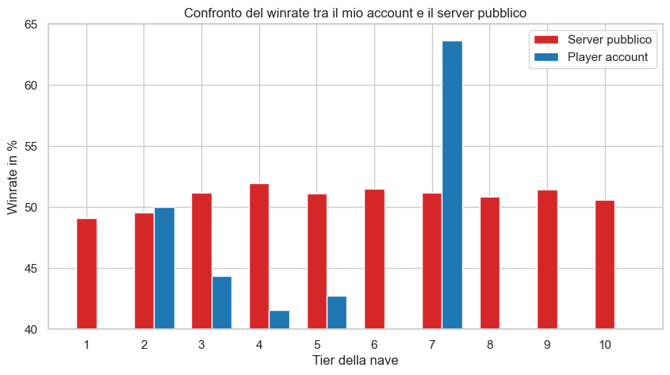

## Confronto statistiche del tier 7

Confronto delle principali statistiche tra il mio account e il server europeo, al tier 7

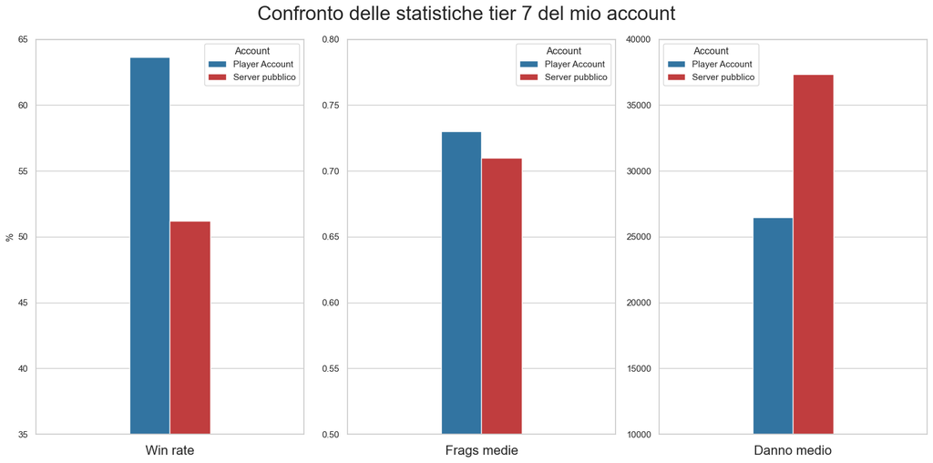

# Premium vs free

Conviene veramente spendere soldi per migliorare?

## Andamento del winrate

Controllo dell'andamento del win rate (% di vittoria)

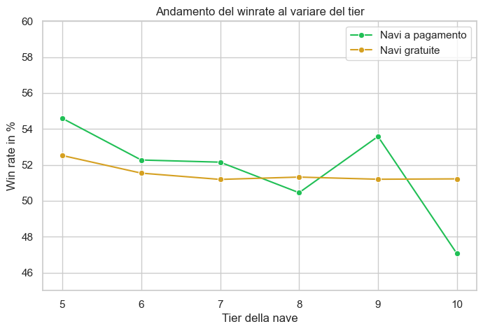

## Che succede a tier 10?

Estrazione dei dati relativi al tier 10, divisi per classe

[output not shown]

## E al tier 8?

Estrazione dei dati delle navi tier 8, divise per classe

[output not shown]

## Statistiche in generale

Confronto delle varie statistiche delle partite tra navi free e premium

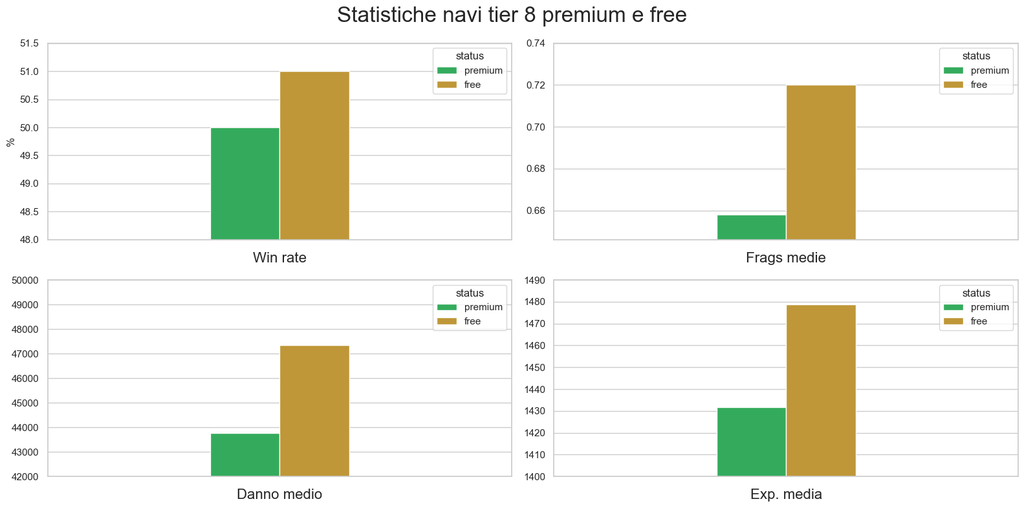

## Corazzate nello specifico

Panoramica delle statistiche delle corazzate

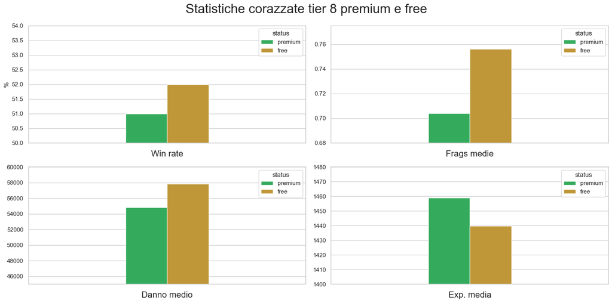

# Risultati e conclusioni